# Linear Regression with Interactions

# Exercise 1

The focus of this exercise is the data set *exercise.txt*. This data set arises from a year-long study of different exercise programs. Researchers were interested in how the weekly number of hours subjects chose to exercise predicted weight loss. The study followed 900 participants over 3 exercise programs: a jogging program, a swimming program, and a reading program (which serves as a control activity).  
The variables in the data set include:

- **loss**: a continuous, normally distributed variable describing the average weekly weight loss for participants. Positive scores denote weight loss, while negative scores denote weight gain. Used as the outcome our regression models.
- **hours**: a continuous variable describing the average number of weekly hours of exercise. Used as the primary continuous predictor.
- **effort**: a continuous variable ranging from 0 to 50, which is an average of weekly subject-reported effort scores, also ranging from 0 to 50, with 0 denoting minimal physical effort and 50 denoting maximum effort.
- **prog**: A 3-category variable detailing which exercise program the subject followed, either jogging=1, swimming=2, or reading=3 (control).
- **female**: A binary categorical variable denoting gender, male=0, female=1.
- **satisfied**: a binary (0/1) variable denoting the subject’s satisfaction (satisfied=1) or dissatisfaction (satisfied=0) with the amount of weight lost.

## 1. Load the Data

First, we load the data into R. Since the data is a .txt file, the function read.table() can be used.

**Tip:** use the argument `header = TRUE` to ensure the variables are saved with the appropriate name.

```r
# load the data
data <- read.table("exercise.txt", header = TRUE)

# view data frame
head(data, 5)
```

```
         prog i    hours female   effort     loss satiscont satisfied
    1 jogging 1 1.836704   male 37.71218 18.02226  3.842609         0
    2 jogging 2 2.389360   male 26.72401 10.18642  4.850140         0
    3 jogging 3 2.362117   male 36.31657 19.74728  5.888355         0
    4 jogging 4 2.520866   male 20.70048  1.88360  6.385125         0
    5 jogging 5 1.889828   male 24.72712 14.24259  4.249327         0
```

## 2. Dummy Variables

First, the researchers would like to know if the average weight loss is same among the 3 exercise programs. In other words, they would like to answer the question: does subscribing to a particular exercise program result in more weight loss than others?

**a. Exercise program is a categorical variable with three categories, this means we will need to utilize dummy variables in our analysis. How many dummy variables are required?**

There are 2 dummy variables required, including a third would provide redundant information. I.e., if someone has a zero in the first dummy and a zero in the second dummy then we know they must belong to the third group. The way these dummy variables are selected is arbitrary; any group can be the reference group.

For example,

| Exercise Program | Dummy 1 | Dummy 2 | Omitted Dummy |
| --- | --- | --- | --- |
| jogging | 0 | 0 | 1 |
| reading | 1 | 0 | 0 |
| swimming | 0 | 1 | 0 |

The variable that is zero across all (included) dummies is considered the reference group. In this case, the reference group is the jogging group.

**Note:** When running a model in R, the variable that comes first alphabetically is selected as the reference group (unless specified otherwise).

**b. What is the null hypothesis of the research question.**

The average weight loss is the same among the 3 exercise programs. Let $\mu_i$ represent the average weight loss in exercise program $i$.

$$H_o: \mu_{jog} = \mu_{read}= \mu_{swim}$$

**c. Write the regression equation that can be used to help answer this research question.**

$$y_i = \beta_0 + \beta_1 * x_{1i} + \beta_2*x_{2i} + \varepsilon_{i}$$
where,

- $i$ indicates an individual,
- $y_i$ = weight loss of individual $i$,
- $x_1$ = a dummy variable, 1 if an individual was in the reading group, otherwise, 0.
- $x_2$ = a dummy variable, 1 if an individual was in the swimming group, otherwise, 0.
- $\varepsilon_{i}$ = random error associated with individual $i$.

**d. Re-write the null hypothesis, this time, using only the regression coefficients.**

$\beta_0$ represents the average expected weight loss for someone in the jogging category. Therefore, if the average weight loss is the same across the categories, this implies that $\beta_1$ and $\beta_2$ are both zero.

$$H_o: \beta_1 = \beta_2= 0$$

**e. Run the above linear model in R.**

**Tips:**

- the lm() command in R requires you to specify the regression equation in the format: dependent variable ~ independent variable.
- when using a categorical predictor (like `prog`), make sure this variable is saved as a factor. This way, R knows it is a categorical variable and it will create dummmy variables for us!

```r
# save variable prog as a factor
data$prog <- as.factor(data$prog)

# linear regression
model <- lm(loss ~ prog, data = data)

# retrieve model summary
summary(model)
```

```
      Call:
      lm(formula = loss ~ prog, data = data)

      Residuals:
           Min       1Q   Median       3Q      Max
      -22.4700  -4.6636  -0.0762   4.1810  28.3304

      Coefficients:
                   Estimate Std. Error t value Pr(>|t|)
      (Intercept)    8.0304     0.4110   19.54   <2e-16 ***
      progreading  -11.8182     0.5813  -20.33   <2e-16 ***
      progswimming  17.7897     0.5813   30.61   <2e-16 ***
      ---
      Signif. codes:  0 '***' 0.001 '**' 0.01 '*' 0.05 '.' 0.1 ' ' 1

      Residual standard error: 7.119 on 897 degrees of freedom
      Multiple R-squared:  0.7457,  Adjusted R-squared:  0.7451
      F-statistic:  1315 on 2 and 897 DF,  p-value: < 2.2e-16
```

**f. What can you conclude? Interpret the intercept, each of the regression coefficients and provide an overall conclusion.**  
$\beta_0$: the average expected weight loss for people in the jogging group is 8.03 pounds.  
$\beta_1$: the difference in average expected weight loss between the jogging group and the reading group. In other words, on average, people in the jogging group lose 11.82 pounds more weight than in the reading group.  
$\beta_2$ the difference in average expected weight loss between the jogging group and the swimming group. In other words, on average, people in the swimming group lost 17.8 pounds more weight than in the jogging group.  
The p-values from the regression output test the null hypothesis that $\beta_i = 0$. Each of the p-values are $< 0.001$ therefore, there is sufficient evidence to conclude that all three of the regression coefficients are significantly non-zero.

## 3. Interaction Effect

The researchers are also interested in determining if the number of hours engaging in a particular activity is related to average weight loss. Let’s investigate if hours of activity is related to weight loss.

**a. Add hours as a predictor to your previous model, and interpret the regression coefficient associated with hours.**

```r
model_2 <- lm(loss ~ prog + hours, data = data)
summary(model_2)
```

```
     Call:
     lm(formula = loss ~ prog + hours, data = data)

     Residuals:
          Min       1Q   Median       3Q      Max
     -23.6622  -5.0540  -0.0708   4.7664  26.5093

     Coefficients:
                  Estimate Std. Error t value Pr(>|t|)
     (Intercept)    1.5353     1.0130   1.516     0.13
     progreading  -11.9613     0.5668 -21.105  < 2e-16 ***
     progswimming  17.7849     0.5664  31.401  < 2e-16 ***
     hours          3.2682     0.4682   6.980 5.74e-12 ***
     ---
     Signif. codes:  0 '***' 0.001 '**' 0.01 '*' 0.05 '.' 0.1 ' ' 1

     Residual standard error: 6.937 on 896 degrees of freedom
     Multiple R-squared:  0.7588,   Adjusted R-squared:  0.758
     F-statistic: 939.5 on 3 and 896 DF,  p-value: < 2.2e-16
```

*Answer* {Here, we see that the regression coefficient for hours is 3.2682 with an associated p-value $<0.001$. This indicates that there is a significant positive association between the hours engaged in activity and average weight loss. Specifically, ever 1 hour increase in activity is associated with a 3.3 pounds increase in weight loss, *after controlling for exercise program*.}

The correct interpretation for the regression coefficient in part a is: ever 1 hour increase in activity is associated with a 3.3 pound increase in weight loss, *after controlling for exercise program*. This implies that no matter what exercise program you belong to, on average, we expect that a 1 hour increase in activity is associated with a 3.3 pound increase in weight loss. Does this seem reasonable?  
We saw in question 2 that the average weight loss was different across the exercise programs. Perhaps it is reasonable to hypothesize that the effect of hours of activity on average weight loss might depend on the activity at hand. For instance, perhaps doing 2 hours of swimming is associated with more weight loss than 2 hours of jogging. Or, for instance, maybe 2 hour of reading is associated with less weight loss than 2 hours of swimming.  
We can determine if the effect of hours of activity (on average weight loss) is dependent on the activity at hand by by checking if there is an *interaction effect* between these hours of activity and exercise program.

**b. First, let’s visualize the scenario. Create a plot with hours along the x-axis, weightloss on the y-axis and a separate regression line for each of the exercise groups. Based on your plot, does the relationship between hours of activity and weight loss appear to be the same across the exercise programs?**

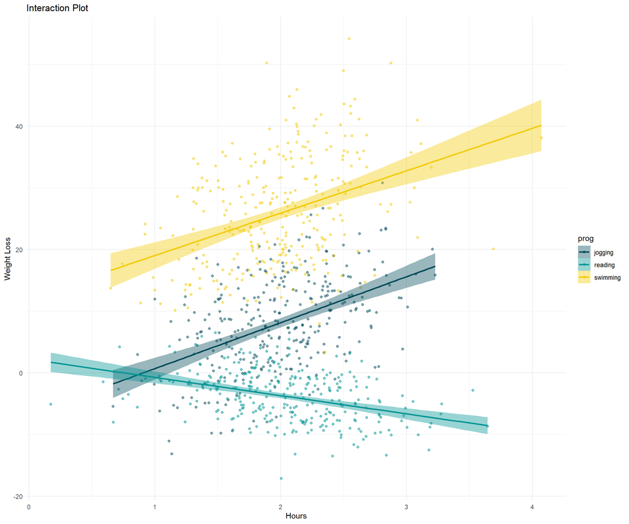

```r
# visualization

library(tidyverse)

data %>%
  ggplot() +
  geom_point( aes(x = hours, y = loss, color = prog), alpha = 0.5) +
  geom_smooth(aes(x = hours, y = loss, color = prog, fill = prog),
              method = lm,
              formula = y~x,
              se = T) +
  theme_minimal() +
  scale_color_manual(values = c("#004A59", "#009494", "#F2CB05")) +
  scale_fill_manual( values = c("#004A59", "#009494", "#F2CB05")) +
  ggtitle("Interaction Plot") +
  xlab("Hours") +
  ylab("Weight Loss")
```

*Answer* {From the plot, we see that on average, as hours of activity increases so does weight loss, if you are in the jogging group or the swimming group. In particular, the rate of increase appears to be the same for the jogging and swimming group. In other words, the relationship between hours of activity and weight loss appears to be the same between the jogging group and the swimming group.

On the other hand, we see that on average, as hours of activity increases, weight loss decreases, if you are in the reading group. This effect is different than what we see with the other two groups.}

Parallel lines on the interaction plot suggest that no interaction is present, while non-parallel lines (lines with different slopes) suggest that there is an interaction effect. Recall that the slope of the regression lines in this context represent the effect of hours on average weight loss. If the slopes are equal then then the effect of hours on average weight loss is the same across the exercise groups. Conversely, if the slopes are significantly different, then the effect of hours on average weight loss depends on the exercise group.  
You can view testing for an interaction effect like testing if the slope of the regression lines are equal across the exercise groups.  
Just like when we compared group means across the exercise groups, dummy variables are used when we compare group regression slopes.

**c. Run a linear regression with this interaction effect in R.**  
**Note:** You can use the following formula to include an interaction effect in your linear model: `loss ~ prog*hours`.

```r
model_3 <- lm(loss ~ prog*hours, data = data)
summary(model_3)
```

```
     Call:
     lm(formula = loss ~ prog * hours, data = data)

     Residuals:
         Min      1Q  Median      3Q     Max
     -24.977  -4.146  -0.213   3.992  25.067

     Coefficients:
                        Estimate Std. Error t value Pr(>|t|)
     (Intercept)         -6.7807     1.6438  -4.125 4.06e-05 ***
     progreading          8.9970     2.2160   4.060 5.34e-05 ***
     progswimming        18.9296     2.2877   8.275 4.66e-16 ***
     hours                7.4527     0.8053   9.255  < 2e-16 ***
     progreading:hours  -10.4089     1.0723  -9.708  < 2e-16 ***
     progswimming:hours  -0.5787     1.1193  -0.517    0.605
     ---
     Signif. codes:  0 '***' 0.001 '**' 0.01 '*' 0.05 '.' 0.1 ' ' 1

     Residual standard error: 6.502 on 894 degrees of freedom
     Multiple R-squared:  0.7885,   Adjusted R-squared:  0.7874
     F-statistic: 666.8 on 5 and 894 DF,  p-value: < 2.2e-16
```

**d. Based on the output, determine if there is a significant interaction effects between hours and exercise group**  
**Note**: An interaction effect between jogging and swimming would appear as jogging:swimming in the R output.

*Answer* {The regression coefficient for the interaction effect between reading and hours is -10.4089 with a p-value $< 0.001$. This indicates that there is a significant interaction between hours and exercise group. In other words, the effect of hours on average weight loss is significantly different between the reading group and the jogging group.

The regression coefficient for the interaction effect between swimming and hours is -0.5787 with a p-value of 0.605. This indicates that the effect of hours on average weight loss is not significantly different between the swimming group and the jogging group}

**e. Write the regression equation for the interaction model.**

$$y_i = \beta_0 + \beta_1 x_{1i} + \beta_2x_{2i} + \beta_3x_{3i} + \beta_4x_{1i}*x_{3i} + \beta_5x_{2i}*x_{3i} + \varepsilon_{i}$$
where,

- $i$ indicates an individual,
- $y_i$ = weight loss of individual $i$,
- $x_1$ = a dummy variable, 1 if an individual was in the reading group, otherwise, 0.
- $x_2$ = a dummy variable, 1 if an individual was in the swimming group, otherwise, 0.
- $x_3$ = a continuous variable, representing hours.
- $\varepsilon_{i}$ = random error associated with individual $i$.

**f. Write the regression equation for each of the exercise programs. What are the intercept and slope for the regression line for each of the groups.**

**Hint:** To arrive at the regression equation for each of the exercise programs, sub in the values of the dummy variables for exercise program. No need to sub anything in for hours.

**Jogging group** ($x_1 = 0, x_2 = 0$): The intercept it $\beta_0$ and slope is $\beta_3$

$$y_i = \beta_0 + \beta_3x_3$$

**Reading group**($x_1 = 1, x_2 = 0$): The intercept is $\beta_0 + \beta_1$ and the slope is $\beta_3+ \beta_4$.

$$y_i = \beta_0 + \beta_1 + \beta_3x_{3i} + \beta_4x_{3i} \ \ \ \Rightarrow \ \ \ y_i = (\beta_0 + \beta_1) + (\beta_3+ \beta_4)x_{3i}$$

$$y_i = \beta_0 + \beta_2 + \beta_3x_{3i} + \beta_5x_{3i} \ \ \ \Rightarrow \ \ \ y_i = (\beta_0 + \beta_2) + (\beta_3+ \beta_5)x_{3i}$$

**Notice**:

From the regression equations, we see that $\beta_1$ represents the difference in regression intercept between the jogging group and the reading group. While $\beta_4$ represents the difference in regression slope between the jogging group and the reading group. Similarly we see that $\beta_2$ represents the difference in regression intercept between the jogging group and the swimming group. While $\beta_5$ represents the difference in regression slope between the jogging group and the swimming group.

**Adding an interaction effect allows the relationship between hours of activity and weightloss to be modelling independently in each group.**

# Exercise 2

For this next example, our focus is the dat set *lowbirth.dat*. We will only consider the following variables:

- **age** age of the mother in years,
- **ht** history of hypertension (1 = yes, 0 = no) and
- **bwt** birth weight in grams

The researchers were interested in investigating if a mother’s age has an effect on the birth weight of their children. Additionally, they would like to know if this effect is modified by the mother’s history of hypertension. Or, in other words, is there an interaction effect between a mother’s age and their history of hypertension.

## 1. Load the data.

**a. Load the data.**

```r
# load the data
dat <- read.table("lowbirth.dat", header = TRUE)
```

**b. View the data frame, report sample size and ensure that ht is saved as a factor.**

```r
# view the data
head(dat, 5)
```

```
       id low age lwt race smoke ptl ht ui ftv  bwt
     1 85   0  19 182    2     0   0  0  1   0 2523
     2 86   0  33 155    3     0   0  0  0   3 2551
     3 87   0  20 105    1     1   0  0  0   1 2557
     4 88   0  21 108    1     1   0  0  1   2 2594
     5 89   0  18 107    1     1   0  0  1   0 2600
```

```r
# sample size
dim(dat)        # N = 189
```

```
     [1] 189  11
```

```r
# ht as factor
dat$ht <- as.factor(dat$ht)
```

**c. How many observations are there in each category of `ht`.**

```r
table(dat$ht)
```

```
      0   1
    177  12
```

## 2. Visualization

**a. let’s start with a visualization. Create a plot with age on the x-axis, bwt on the y-axis and separate regression lines for ht.**

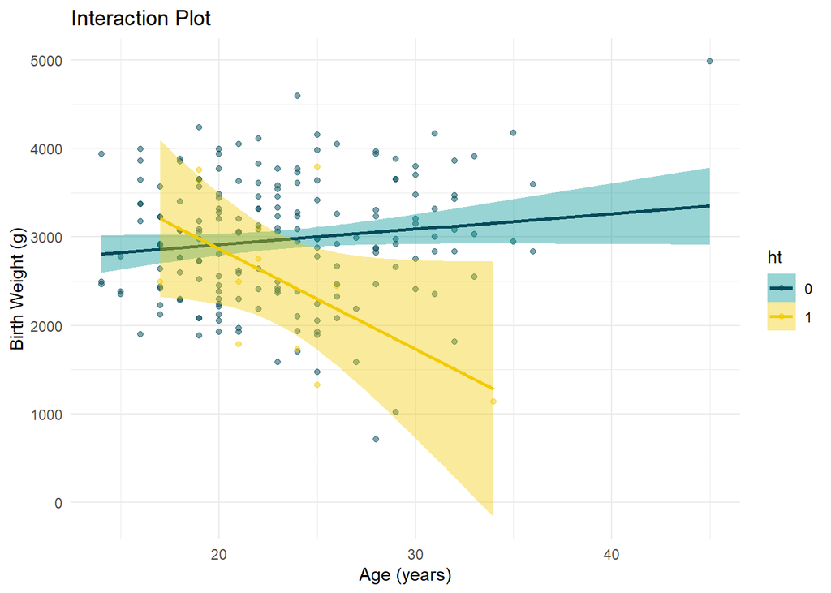

```r
# visualization

dat %>%
  ggplot() +
  geom_point( aes(x = age, y = bwt, color = ht), alpha = 0.5) +
  geom_smooth(aes(x = age, y = bwt, color = ht, fill = ht),
              method = lm,
              formula = y~x,
              se = T) +
  theme_minimal() +
  scale_color_manual(values = c("#004A59", "#F2CB05")) +
  scale_fill_manual( values = c("#009494", "#F2CB05")) +
  ggtitle("Interaction Plot") +
  xlab("Age (years)") +
  ylab("Birth Weight (g)")
```

**b. Based on your plot, does the effect of mother’s age appear to depend on the mother’s hypertension history?**  
Answer{Yes, the effect of mother’s age does appear to depend on the mother’s hypertension history. The regression lines for mothers with and without a history of hypertension are not parallel. In particular, as age increases, mothers with a history of hypertension tend to have children with a lower birth weight. Meanwhile, for mothers without a history of hypertension, an increase in age is associated with a slight increase in birthweight.}

**c. Why are the standard error bars so much larger for the `ht =1` group than the `ht = 0` group.**  
Answer{ There are far fewer observations in the ht = 1 class, therefore, we have far less certainty about the slope of the regression line. }

## 3. Analysis

**a. Fit a model with bwt as dependent and with ht and age as independent variables. Also include the interaction between age and ht in the model. Retrieve the model summary**

```r
# fit the model
int_mod <- lm(bwt ~ age + ht + age*ht, data = dat)

# model summary
summary(int_mod)
```

```
     Call:
     lm(formula = bwt ~ age + ht + age * ht, data = dat)

     Residuals:
         Min      1Q  Median      3Q     Max
     -2345.9  -540.4    42.8   528.2  1638.8

     Coefficients:
                 Estimate Std. Error t value Pr(>|t|)
     (Intercept) 2566.895    238.466  10.764  < 2e-16 ***
     age           17.430      9.992   1.744  0.08274 .
     ht1         2570.179   1149.784   2.235  0.02659 *
     age:ht1     -130.899     49.281  -2.656  0.00859 **
     ---
     Signif. codes:  0 '***' 0.001 '**' 0.01 '*' 0.05 '.' 0.1 ' ' 1

     Residual standard error: 710.7 on 185 degrees of freedom
     Multiple R-squared:  0.06467,  Adjusted R-squared:  0.04951
     F-statistic: 4.264 on 3 and 185 DF,  p-value: 0.006124
```

**b. Center the variable age, and fit the regression model again.**

```r
# center age
dat <-
  dat %>%
  mutate_at("age", scale, scale = F)

# fit model
ac_int_mod <- lm(bwt ~ age + ht + age*ht, data = dat)

# retrieve summary
summary(ac_int_mod)
```

```
     Call:
     lm(formula = bwt ~ age + ht + age * ht, data = dat)

     Residuals:
         Min      1Q  Median      3Q     Max
     -2345.9  -540.4    42.8   528.2  1638.8

     Coefficients:
                 Estimate Std. Error t value Pr(>|t|)
     (Intercept) 2971.931     53.423  55.630  < 2e-16 ***
     age           17.430      9.992   1.744  0.08274 .
     ht1         -471.653    212.583  -2.219  0.02772 *
     age:ht1     -130.899     49.281  -2.656  0.00859 **
     ---
     Signif. codes:  0 '***' 0.001 '**' 0.01 '*' 0.05 '.' 0.1 ' ' 1

     Residual standard error: 710.7 on 185 degrees of freedom
     Multiple R-squared:  0.06467,  Adjusted R-squared:  0.04951
     F-statistic: 4.264 on 3 and 185 DF,  p-value: 0.006124
```

## 4. Interpretations

**b. For the model where age is centered, interpret the intercept and all three regression coefficients**

$\beta_0$: The expected birth weight (in grams) for a mother of average age with no history of hypertension.  
$\beta_{age}$: Each one year increase in age is associated with a 17.430 g increase in birth weight for mothers with no history of hypertension. This effect is not statistically significant ($p = 0.08$).  
$\beta_{ht1}$: The expected difference in average birth weight between mothers with and without a history of hypertension, for mothers of average age.  
$\beta_{interaction}$: The expected difference in the regression slope for mothers with a history of hypertension vs. mothers without a history of hypertension. The interaction effect is statistically significant ($p = 0.008$).

**c. Do these models capture the information in the data equally well?**  
Answer{Yes, these models are statistically equivalent. Centering is used to enhance the interperetability of the output, but the results are equally valid.}